# Informe de Resultados Red Multiambiental de Evaluación de híbridos de Girasol 2024/25

[figure not shown]

[figure not shown]

[figure not shown]

[figure not shown]

[figure not shown]

# Informe de Resultados Red Multiambiental de Evaluación de híbridos de Girasol 2024/25

# 1 Introducción

El rendimiento de un cultivo (fenotipo) es función del resultado acumulativo de un número de factores que inciden en la interacción entre la expresión del material genético del cultivar o variedad (genotipo) y las condiciones en las cuales la planta crece (ambiente). Los ambientes difieren en la cantidad y calidad de recursos que están disponibles para las plantas (agua, nutrientes y radiación), y las plantas capturan y convierten dichos recursos en biomasa y órganos de interés comercial, según su carga genética, que a su vez es modulada por el ambiente (Yan y Kang, 2002).

Según el objetivo de mejoramiento, los genotipos pueden ser seleccionados para mejorar su adaptación a un amplio rango de condiciones ambientales o bien para condiciones más específicas. En este último caso, la adaptación sitio-específica de los genotipos se relaciona con el fenómeno denominado *interacción genotipo-ambiente* (**GA**), el cual se observa cuando la performance relativa de los fenotipos depende del ambiente en el que crecen (Malosetti et al., 2013).

La interacción **GA** reduce la asociación entre los valores fenotípicos y genotípicos, lo cual puede ocasionar que los genotipos seleccionados por su performance en un ambiente tengan mal desempeño en otro. Es por ello que en presencia de fuerte interacción **GA**, gran parte del éxito productivo del cultivo de girasol es el resultado de la elección de los materiales más aptos para cada ambiente.

## 1.1 Objetivos

- Resumir los datos de rendimiento de los genotipos de girasol evaluadas en la Red CREA RNSF de Ensayos Multiambientales durante la campaña 2024/25.
- Analizar estadísticamente los datos comparando los genotipos globalmente en toda la red en la campaña 2024/25.
- Explorar y describir los patrones de la interacción **GA** en la campaña 2024/25 en particular y considerando el conjunto de ambientes explorados en las distintas localidades y campañas.

# 2 Metodología

## 2.1 Sitios experimentales

Durante la campaña 2024/25 se llevaron adelante ensayos comparativos de rendimiento de genotipos de girasol en 5 localidades del Norte de la Provincia de Santa Fe. Los sitios seleccionados para los ensayos en cada localidad corresponden a establecimientos productivos de miembros CREA de la Región Norte de Santa Fe. La distribución espacial e información de los ensayos se muestra en la Figura 2.1. A modo de referencia se incluye la ubicación de los ensayos de las campañas anteriores.

Mapa interactivo: se puede hacer zoom o mostrar/ocultar información de cada ensayo (Fecha de siembra, antecesor, densidad, fertilizacion, etc) haciendo haciendo clik sobre los puntos de la campaña 2024/25.

[interactive chart not shown]

Figura 2.1: Distribución espacial de las localidades incluidas en la campaña 2024/25 y anteriores

En cada sitio se establecieron ensayos comparativos de rendimiento (ECR) utilizando un diseño experimental sin réplicas con controles sistemáticos (Kempton, 1997). Los materiales fueron sembrados con espaciamiento entre surco (EES) de 52 cm en franjas de 4.16 m de ancho por de 200 m de longitud.

## 2.2 Condiciones climáticas

En la Figura 2.2 se resumen las precipitaciones mensuales de la presente campaña así como la serie 1945-2020 registrada en la EEA INTA Reconquista.

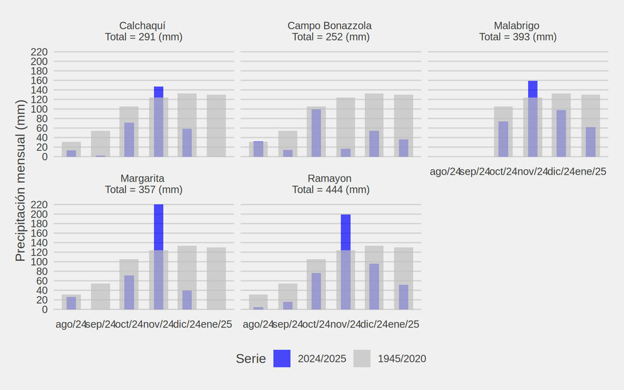

Figura 2.2: Precipitaciones mensuales totales por localidad durante la campaña 2024/25 y serie 1945/2020 del EEA INTA Reconquista

Se observan precipitaciones mensuales similares o por encima del promedio histórico durante el mes Noviembre en todas las localidades excepto `Campo Bonazzola`, donde fueron significativamente menores. Los totales mensuales en los demás meses fueron inferiores al histórico salvo en el mes de agosto en la localidad `Campo Bonazzola`, donde el total mensual supero levemente al histórico. En enero no se registraron precipitaciones en `Margarita` y `Calchaquí`.

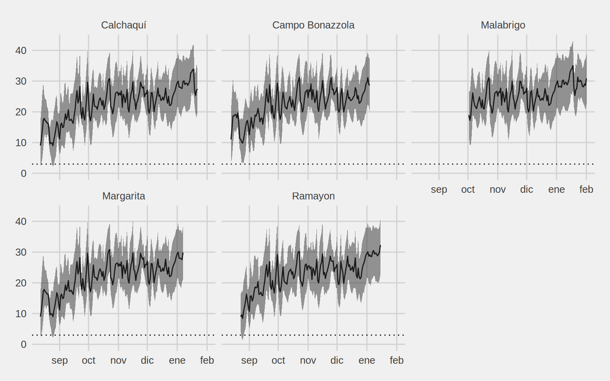

En cuanto a la marcha del régimen térmico, en ninguna de las localidades se registraron heladas tardías.

## 2.3 Genotipos

Los tratamientos evaluados en la campania 2024/25 fueron 21 genotipos. En la Tabla 2.1 se indican las localidades en las que fueron evaluados.

Tabla 2.1: Cultivares evaluadas y localidades en las que fueron incluidas

Semillero

Genotipo

Localidades

Calchaquí

Campo Bonazzola

Malabrigo

Margarita

Ramayon

ACA 216 CLDM

ACA 220 CL

ADV 5407 CL

ADV 5420 CLP

[figure not shown]

INSUN 2277 CL

BRV 3633 CP

BRV 4225 CL

[figure not shown]

CACIQUE 2.23 CLP

KLEIN G 26-25 CL

KLEIN G 2750 CL

[figure not shown]

EXP LG 344 CL

NK 3969 CL

NK 3970 CL

NK 3939 CL

[figure not shown]

NS 1115 CL

NUSOL 4175 CL

P 1800 CLP

RGT ARLLEM CLP

RGT HUEMULL CL

RGT OBELLISCO CL

[figure not shown]

SPS 3125 CL

Todos los genotipos estuvieron presentes en las 5 localidades. El genotipo `NK 3970 CL` actuó como referencia o *check*, con más de una réplica por localidad salvo en `Campo Bonazzola` donde el material `NK 3969 CL` actuó como referencia o *check*.

Para el análisis global se utilizaron los datos de todos los genotipos presentes en al menos tres localidades.

# 3 Resultados

## 3.1 Rendimiento testigo

En la Tabla 3.1 se muestran los rendimientos promedio por localidad de los genotipos utilizados como *check* o control.

Tabla 3.1: Rendimiento seco medio y coeficiente de variación por localidad de los genotipos utilizados como *check*

| Localidad | Genotipo | media | CV | min | max |
| --- | --- | --- | --- | --- | --- |
| Calchaquí | NK 3970 CL | 3659 | 7 | 3450 | 4049 |
| Campo Bonazzola | NK 3969 CL | 2907 | 4 | 2687 | 2991 |
| Malabrigo | NK 3970 CL | 2651 | 15 | 2065 | 3021 |
| Margarita | NK 3970 CL | 3541 | 8 | 3128 | 3761 |
| Ramayon | NK 3970 CL | 3476 | 5 | 3293 | 3668 |

La Tabla 3.2 muestra el stand de plantas promedio logrado en las distintas localidades.

Tabla 3.2: Stand de plantas logrado en cada localidad

| Localidad | Promedio | CV (%) |
| --- | --- | --- |
| Calchaquí | 35656 | 17 |
| Campo Bonazzola | 33708 | 6 |
| Malabrigo | 43656 | 9 |
| Margarita | 44688 | 8 |
| Ramayon | 52201 | 10 |

Las localidades en general mostraron baja variación de stand de plantas logrado, CV en torno al 8-10%, a excepción de `Calchaquí` que mostró un CV mayor de 17%. El mayor stand promedio se logró en `Ramayón`, un 30% mayor que el promedio del resto.

## 3.2 Rendimientos por Localiad

Las Figuras 3.1 y 3.2 muestran los rendimientos medios corregidos por %MG y el %MG por localidad, respectivamente. La línea continua representa el promedio en toda la campaña.

*Gráficos interactivos: se puede hacer zoom o mostrar/ocultar los grupos de datos haciendo doble-click en la leyenda.*

### 3.2.1 Rendimiento corregido por %MG

[interactive chart not shown]

Figura 3.1: Rendimiento medio corregido 42% MG y desvío estándar por Localidad

Se observaron rendimientos promedios alrededor de los 3000 kg/ha, siendo superiores en las localidades de `Margarita`, `Ramayón` y `Calchaquí`. En general las parcelas con *checks* estuvieron entorno o superaron los rendimientos promedio de la localidad.

### 3.2.2 Materia grasa (%MG)

[interactive chart not shown]

Figura 3.2: Contenido de materia grasa (%MG) promedio y desvío estándar por Localidad

## 3.3 Rendimientos por Genotipo

En la Figura 3.3 y 3.4 se presentan los valores medios y desviaciones estándar de los rendimientos corregidos por %MG y el %MG de los genotipos considerando la variabilidad entre localidades.

*Gráficos interactivos: se puede hacer zoom o mostrar/ocultar los grupos de datos haciendo doble-click en la leyenda.*

### 3.3.1 Rendimiento corregido

[interactive chart not shown]

Figura 3.3: Rendimientos medios y desvio estándar de los genotipos

En general todos los genotipos presentaron rendimientos medios entre 2300 y 3600 kg ha<sup>-1</sup>. La amplitud de las barras de cada material representan las diferencias de variabilidad entre ambientes la cual fue relativamente baja, salvo para `ACA 220 CL` y `P 1800 CL PLUS`. Entre los materiales con mayor rendimiento corregido se encuentran: `INSUN 2277 CL`, `NUSOL 4175 CL`, `NK 3939 CL`, y `NK 3969 CL`, con rendimientos promedio entorno a 3500-3600 kg, a través de las localidades.

### 3.3.2 Materia grasa (%MG)

[interactive chart not shown]

Figura 3.4: Contenido de MG medio y desvio estándar de los genotipos

En cuanto al contenido promedio de %MG, los promedios de cada genotipo variaron entre ente 48 y 56%, siendo `NK 3969 CL`, `INSUN 2277 CL`, `SPS 3125 CL`, y `ADV 5407 CL` los que superaron los 55%. En contrapartida, el material `KLEIN 5 2750 CL` y `EXP LG 344 CL` presentaron valores de MG consistentemente muy inferiores al resto pero superiores a 48%.

## 3.4 Rendimientos promedio y CV

En las Tablas 3.3 y 3.4 se presentan los promedios y $CV$ por `Genotipo` y `Localidad`, del rendimiento ajustados por MG y %MG expresados en kg/ha y base 100. Los genotipos están **ordenados en función del valor relativo promedio**. Los colores están ordenados en funión del valor relativo de cada localidad.**

Los datos pueden descargarse de los siguientes enlaces: medias_CV_rend_real.xlsx, medias_CV_rend_42MG.xlsx, medias_CV_MG.xlsx

### 3.4.1 Redimientos ajustados 42% MG

Tabla 3.3: Rendimiento seco medio corregido por materia grasa (kg/ha) y coeficiente de variación por genotipo y localidad

|  | Localidad Calchaquí | Localidad Campo Bonazzola | Localidad Malabrigo | Localidad Margarita | Localidad Ramayon | Promedio | CV |  |  |
| --- | --- | --- | --- | --- | --- | --- | --- | --- | --- |
| INSUN 2277 CL | 117 (3870) | 111 (3014) | 129 (3296) | 128 (4141) | 109 (3800) |  |  | 119 (3624) | 8 (13) |
| NUSOL 4175 CL | 123 (4062) | 109 (2966) | 129 (3286) | 100 (3234) | 118 (4101) | 116 (3530) | 10 (15) |  |  |
| NK 3939 CL | 113 (3731) | 111 (3003) | 110 (2793) | 126 (4055) | 116 (4030) | 115 (3522) | 6 (17) |  |  |
| NK 3969 CL | 115 (3789) | 107 (2907) | 124 (3172) | 111 (3569) | 118 (4115) | 115 (3510) | 6 (14) |  |  |
| SPS 3125 CL | 98 (3230) | 114 (3087) | 93 (2379) | 114 (3688) | 114 (3984) | 107 (3274) | 10 (19) |  |  |
| NK 3970 CL | 111 (3659) | 112 (3037) | 104 (2651) | 110 (3541) | 100 (3476) | 107 (3273) | 5 (13) |  |  |
| BRV 4225 CL | 118 (3889) | 100 (2728) | 113 (2888) | 95 (3054) | 108 (3767) | 107 (3265) | 9 (16) |  |  |
| ADV 5420 CLP | 86 (2831) | 107 (2903) | 117 (2978) | 107 (3459) | 110 (3833) | 105 (3201) | 11 (13) |  |  |
| CACIQUE 2.23 CLP | 99 (3256) | 101 (2734) | 112 (2858) | 116 (3734) | 87 (3030) | 103 (3122) | 11 (13) |  |  |
| ACA 216 CLDM | 86 (2839) | 93 (2534) | 111 (2827) | 114 (3693) | 99 (3463) | 101 (3071) | 12 (16) |  |  |
| ADV 5407 CL | 96 (3176) | 100 (2710) | 108 (2744) | 94 (3040) | 106 (3681) | 101 (3070) | 6 (13) |  |  |
| NS 1115 CL | 105 (3471) | 96 (2597) | 98 (2489) | 102 (3302) | 100 (3495) | 100 (3071) | 3 (16) |  |  |
| RGT HUEMULL CL | 113 (3737) | 92 (2510) | 95 (2431) | 88 (2833) | 94 (3277) | 96 (2958) | 10 (19) |  |  |
| ACA 220 CL | 100 (3290) | 109 (2960) | 63 (1605) | 111 (3589) | 89 (3101) | 94 (2909) | 21 (26) |  |  |
| P 1800 CLP | 99 (3271) | 102 (2775) | 74 (1890) | 106 (3427) | 90 (3132) | 94 (2899) | 14 (21) |  |  |
| KLEIN G 2750 CL | 99 (3259) | 91 (2479) | 93 (2375) | 59 (1903) | 101 (3529) | 89 (2709) | 19 (25) |  |  |
| BRV 3633 CP | 82 (2716) | 87 (2376) | 75 (1907) | 94 (3023) | 90 (3147) | 86 (2634) | 9 (19) |  |  |
| RGT OBELLISCO CL | 74 (2459) | 76 (2051) | 82 (2100) | 90 (2895) | 97 (3378) | 84 (2577) | 12 (22) |  |  |
| RGT ARLLEM CLP | 78 (2582) | 92 (2499) | 79 (2021) | 76 (2469) | 92 (3219) | 83 (2558) | 10 (17) |  |  |
| EXP LG 344 CL | 89 (2925) | 90 (2455) | 91 (2319) | 60 (1936) | 62 (2160) | 78 (2359) | 20 (16) |  |  |
| Promedio | 100 (3302) | 100 (2716) | 100 (2550) | 100 (3229) | 100 (3486) | — | — |  |  |

El nivel de variabilidad de los genotipos a través de los ambientes mostró valores menores a 28% en los datos expresados en rendimiento absoluto corregido por 42% de MG. Aproximadamente el 50% de los genotipos tuvo CV de rendimiento entre 13 y 19%. Al considerar los valores relativos, la variabilidad se reduce (el 50% de los híbridos pasa a tener CV entre 7 y 12%), ya que se remueve en parte el efecto de la variación entre localidades.

Los materiales `INSUN 2277 CL` , `NUSOL 4175 CL`, `NK 3939 CL` y `NK 3969 CL` se ubicaron entre los primeros a nivel global y en la mayoría de los ambientes. El resto mostró cambios en la posición dentro de cada localidad.

### 3.4.2 Materia grasa (%MG)

Tabla 3.4: Contenido de MG (%) y coeficiente de variación por genotipo y localidad

|  | Localidad Calchaquí | Localidad Campo Bonazzola | Localidad Malabrigo | Localidad Margarita | Localidad Ramayon | Promedio | CV |  |  |
| --- | --- | --- | --- | --- | --- | --- | --- | --- | --- |
| NK 3969 CL | 108 (55) | 105 (56) | 110 (56) | 105 (55) | 108 (57) |  |  | 107 (56) | 2 (1) |
| INSUN 2277 CL | 108 (55) | 105 (56) | 108 (55) | 107 (56) | 105 (55) | 107 (55) | 1 (1) |  |  |
| SPS 3125 CL | 108 (55) | 107 (57) | 108 (55) | 101 (53) | 107 (56) | 106 (55) | 3 (3) |  |  |
| ADV 5407 CL | 106 (54) | 103 (55) | 110 (56) | 105 (55) | 103 (54) | 105 (55) | 3 (2) |  |  |
| BRV 4225 CL | 106 (54) | 103 (55) | 106 (54) | 103 (54) | 103 (54) | 104 (54) | 2 (1) |  |  |
| NK 3970 CL | 104 (53) | 103 (55) | 104 (53) | 105 (55) | 103 (54) | 104 (54) | 1 (2) |  |  |
| NK 3939 CL | 106 (54) | 101 (54) | 106 (54) | 105 (55) | 103 (54) | 104 (54) | 2 (1) |  |  |
| ADV 5420 CLP | 96 (49) | 107 (57) | 100 (51) | 103 (54) | 101 (53) | 101 (53) | 4 (6) |  |  |
| NUSOL 4175 CL | 102 (52) | 101 (54) | 102 (52) | 98 (51) | 103 (54) | 101 (53) | 2 (3) |  |  |
| CACIQUE 2.23 CLP | 100 (51) | 101 (54) | 100 (51) | 101 (53) | 101 (53) | 101 (52) | 1 (3) |  |  |
| NS 1115 CL | 100 (51) | 99 (53) | 102 (52) | 99 (52) | 97 (51) | 99 (52) | 2 (2) |  |  |
| ACA 220 CL | 102 (52) | 101 (54) | 87 (44) | 103 (54) | 97 (51) | 98 (51) | 7 (8) |  |  |
| RGT ARLLEM CLP | 96 (49) | 99 (53) | 96 (49) | 96 (50) | 101 (53) | 98 (51) | 2 (4) |  |  |
| BRV 3633 CP | 94 (48) | 96 (51) | 96 (49) | 98 (51) | 101 (53) | 97 (50) | 3 (4) |  |  |
| RGT HUEMULL CL | 98 (50) | 96 (51) | 98 (50) | 96 (50) | 95 (50) | 97 (50) | 1 (1) |  |  |
| RGT OBELLISCO CL | 96 (49) | 90 (48) | 94 (48) | 96 (50) | 99 (52) | 95 (49) | 3 (3) |  |  |
| ACA 216 CLDM | 90 (46) | 98 (52) | 93 (47) | 96 (50) | 93 (49) | 94 (49) | 3 (5) |  |  |
| P 1800 CLP | 92 (47) | 96 (51) | 93 (47) | 96 (50) | 95 (50) | 94 (49) | 2 (4) |  |  |
| EXP LG 344 CL | 90 (46) | 92 (49) | 94 (48) | 94 (49) | 93 (49) | 93 (48) | 2 (3) |  |  |
| KLEIN G 2750 CL | 92 (47) | 96 (51) | 89 (45) | 94 (49) | 93 (49) | 93 (48) | 3 (5) |  |  |
| Promedio | 100 (51) | 100 (53) | 100 (51) | 100 (52) | 100 (53) | — | — |  |  |

La variación de la mayoría de los contenidos de MG entre ambientes y entre híbridos fue baja (CV 1-8%). En este caso los materiales `ADV 5407 CL`, `NK 3969 CL`, `INSUN 2277 CL` y `SPS 3125` mostraron contenidos en torno al 6-8% superior al promedio, y bastante consistentes a través de las localidades.

### 3.4.3 Gráfico

La Figura 3.5 presenta la relación entre los rendimientos medios (corregido por MG 42%) expresados en valores relativos y la estabilidad (indicada por el CV) de los genotipos a través de las localidades incluidas en la red durante la campaña 2024/25.

[interactive chart not shown]

Figura 3.5: Rendimiento seco medio corregido a 42% MG (en kg/ha) y CV (%) de los genotipos evaluados en la campaña 2024/25

## 3.5 Diferencias entre genotipos

En la Tabla 3.5 se presentan los resultados del análisis de la varianza (ANOVA) del modelo mixto ajustado:

Tabla 3.5: Tabla de Análisis de la Varianza del modelo lineal mixto

|  | gl num | F | Valor p |
| --- | --- | --- | --- |
| (Intercept) | 1 | 7,959.53 | 0.00000 |
| Localidad | 4 | 27.53 | 0.00000 |
| Genotipo | 19 | 5.50 | 0.00000 |

Tabla 3.6: Rendimientos intervalos de confianza 90% ajustados por el modelo-mixto

|  | Rend. medio | Error estándar | gl | LI IC90 | LS IC90 | grupo |
| --- | --- | --- | --- | --- | --- | --- |
| INSUN 2277 CL | 3624 | 153 | 76 | 3369 | 3879 | a |
| NUSOL 4175 CL | 3530 | 153 | 76 | 3275 | 3785 | a |
| NK 3939 CL | 3522 | 153 | 76 | 3267 | 3778 | a |
| NK 3969 CL | 3510 | 153 | 76 | 3255 | 3766 | a |
| SPS 3125 CL | 3274 | 153 | 76 | 3018 | 3529 | ab |
| NK 3970 CL | 3273 | 153 | 76 | 3018 | 3528 | ab |
| BRV 4225 CL | 3265 | 153 | 76 | 3010 | 3520 | ab |
| ADV 5420 CLP | 3201 | 153 | 76 | 2946 | 3456 | ab |
| CACIQUE 2.23 CLP | 3122 | 153 | 76 | 2867 | 3378 | ab |
| ACA 216 CLDM | 3071 | 153 | 76 | 2816 | 3326 | abc |
| NS 1115 CL | 3071 | 153 | 76 | 2816 | 3326 | abc |
| ADV 5407 CL | 3070 | 153 | 76 | 2815 | 3325 | abc |
| RGT HUEMULL CL | 2958 | 153 | 76 | 2702 | 3213 | abc |
| ACA 220 CL | 2909 | 153 | 76 | 2654 | 3164 | abc |
| P 1800 CLP | 2899 | 153 | 76 | 2644 | 3154 | abc |
| KLEIN G 2750 CL | 2709 | 153 | 76 | 2454 | 2964 | bc |
| BRV 3633 CP | 2634 | 153 | 76 | 2379 | 2889 | bc |
| RGT OBELLISCO CL | 2577 | 153 | 76 | 2321 | 2832 | bc |
| RGT ARLLEM CLP | 2558 | 153 | 76 | 2303 | 2813 | bc |
| EXP LG 344 CL | 2359 | 153 | 76 | 2104 | 2614 | c |

El cuadro anterior representa el ranking de genotipos ordeandos por el rendimiento global para la zona de influencia de la Red. El rendimiento medio representa la mejor estimación global del rendimiento de cada genotipo para la región en general a partir de la información obtenida en el presente ensayo. Este valor estimado se acompaña de los límites de un intervalo de confianza (LI IC90 y LS IC90) los cuales representan la región donde se encuentra el verdadero valor del rendimiento.

Considerando la red globalmente, el ranking de materiales muestra diferencias entre `INSUN 2277 CL`, `NUSOL 4175 CL`, `NK 3939 CL` y `NK 3969 CL`, con un rendimeinto global entre 3624 y 3510 kg ha<sup>-1</sup>, con el grupo comprendido entre `KLEIN G 2750 CL` y `EXP LG 344 CL`, cuyos rendimientos medios fueron entre 2709 y 2359 kg ha<sup>-1</sup>. No se detectaron diferencias significativas entre los materiales comprendidos entre `INSUN 2277 CL` y `P 1800 CLP`.

## 3.6 Interacción **GA**

### 3.6.1 Campaña actual

Las diferencias de los rendimientos medios de cada localidad resumen la heterogeneidad de condiciones ambientales a las cuales fueron sometidos los genotipos evaluados. Utilizando esta información se construye un índice ambiental (`IA`) que se utiliza para modelar la interacción genotipo x ambiente a partir de rendimientos de cada genotipo y ambiente. En la Tabla 3.7 se presenta la tabla de ANOVA del modelo.

Tabla 3.7: Tabla de ANOVA del modelo de regresión para la interacción GxA

| Fuente | gl | SC | CM | F | Valor p |
| --- | --- | --- | --- | --- | --- |
| Localidad | 4 | 12928050.54 | 3232012.64 | 24.59 | <0.0001 |
| Genotipo | 19 | 12268588.19 | 645715.17 | 4.91 | <0.0001 |
| Genotipo:IA | 19 | 1428678.84 | 75193.62 | 0.57 | 0.9108 |
| Residuals | 57 | 7493223.02 | 131460.05 |  |  |

Según este análisis, no se detecta interacción significativa entre los materiales evaluados y el índice ambiental (p = 0.91). Esto implica que las diferencias de *sensibilidad* observadas no resultaron en variaciones significativas de las pendientes de la relación `IA` y rendimiento en el rango de valores de IA explorados.

En la Figura 3.6 se presentan las gráficas correspondientes a las normas de reacción a los cambios del `IA` en relación a la respuesta promedio (recta 1:1).

*Gráficos interactivos: se puede hacer zoom o mostrar/ocultar los grupos de datos haciendo doble-click en la leyenda. Por defecto se muestra el primer genotipo, pero haciendo click o doble-click sobre los nombres de los genotipos se pueden agregar/remover rectas para comparar.*

[interactive chart not shown]

Figura 3.6: Respuesta diferencial de cada Genotipo a los cambios del IA

Las pendientes ($\beta$) de las rectas (línea sólida de color) representan la sensibilidad de cada genotipo a la calidad del ambiente caracterizada por el rendimiento medio de la localidad. La sensibilidad promedio (línea punteada) representa la respuesta general de todos los genotipos. Para un genotipo cualquiera, si el valor de la pendiente es $\beta_i > 1$, el genotipo en cuestión tiene mayor sensibilidad a los cambios de calidad del ambiente (a mayor calidad ambiental, mayor rendimiento, y vice versa). En cambio si $\beta_i < 1$, entonces el genotipo es menos sensible y tendría mejores respuestas en ambientes malos y respuestas inferiores al promedio en ambientes buenos. Las diferencias entre las pendientes de los distintos genotipos representa la interacción **GA**.

A modo descriptivo los valores estimados de los $\beta$ para algunos genotipos, como por ejemplo P 1800 CLP, SPS 3125 CL, NK 3939 CL, y ACA 220 CL mostraron pendientes positivas 25% mayores al promedio general. En el otro extremo, EXP LG 344 CL, CACIQUE 2.23 CLP, y ADV 5420 CLP fueron los materiales con menor sensibilidad (pendientes 25% menores a 1). No obstante, sólo en `EXP LG 344 CL` la pendiente fue estadísticamente distintas de la recta 1:1.

El siguiente gráfico muestra la relación entre las pendientes estimadas y los rendimientos medios de cada genotipo.

[interactive chart not shown]

Figura 3.7: Coeficiente de sensibilidad vs rendimiento medio de los genotipos a través de las localidades

Se observa que entre los materiales con mayor rendimiento promedio, los valores de sensibilidad fueron consistentemente superiores a 1, indicando mayor sensibilidad.

### 3.6.2 Últimas tres campañas

Al considerar los ambientes evaluados en las últimas 3 campañas (combinacion localidad x campaña), sólo 5 genotipos estuvieron presentes en los 14 ambientes explorados en las últimas 3 campañas. En la Tabla 3.8 se presenta la tabla de ANOVA del modelo de regresión de la media ajustado.

Tabla 3.8: Tabla de ANOVA del modelo de regresión para la interacción GxA últimas 3 campañas.

| Fuente | gl | SC | CM | F | Valor p |
| --- | --- | --- | --- | --- | --- |
| Localidad | 9 | 15140980.53 | 1682331.17 | 16.61 | <0.0001 |
| Genotipo | 4 | 4680828.13 | 1170207.03 | 11.55 | <0.0001 |
| Genotipo:IA | 5 | 22840663.82 | 4568132.76 | 45.10 | <0.0001 |
| Residuals | 51 | 5166302.70 | 101300.05 |  |  |

Según este análisis se detecta interacción significativa entre los materiales evaluados y el índice ambiental (p < 0.0001). Esto implica que al menos uno de los genotipos mostró una norma de reacción con pendiente distinta de 1, es decir, sensibilidad diferente al promedio. La Table 3.9 muestra los valores de pendiente estimados.

Tabla 3.9: Penidentes estimadas últimas 3 campañas.

| Genotipo | Beta | Error estándar | gl | LI IC95 | LS IC95 |
| --- | --- | --- | --- | --- | --- |
| NK 3939 CL | 1.22 | 0.12 | 60 | 0.97 | 1.47 |
| NK 3969 CL | 1.13 | 0.12 | 60 | 0.88 | 1.38 |
| ACA 216 CLDM | 1.06 | 0.12 | 60 | 0.82 | 1.31 |
| ADV 5407 CL | 0.98 | 0.12 | 60 | 0.73 | 1.23 |
| RGT OBELLISCO CL | 0.78 | 0.12 | 60 | 0.53 | 1.03 |

Según la tabla anterior se observa que `NK 3939 CL` tuvo un valor de sensibilidad marginalmente superior a la norma general (recta 1:1). En la Figura 3.8 se presentan las gráficas correspondientes a las normas de reacción a los cambios del `IA` en relación a la respuesta promedio (recta 1:1). Por defecto se muestra el primer genotipo, pero haciendo click o doble-click sobre los nombres de los genotipos se pueden agregar/remover rectas para comparar.

[interactive chart not shown]

Figura 3.8: Respuesta diferencial de cada Genotipo a los cambios del IA ultimas 3 campañas

Según el gráfico anterior se observa la menor pendiente de `RGT OBELLISCO CL` y mayor pendiente de `NK 3939 CL`. En este caso, estos materiales se diferencian en su respuesta a los ambientes de mayor potencial. También se observa un mayor rendimiento medio y sensibilidad de `NK 3939 CL`. En este caso, el rendimiento es superior al promedio general (linea punteada) en todo el rango de ambientes explorados, a su vez, aumenta a mayor calidad del ambiente.

## 3.7 Calidad de grano

### 3.7.1 Humedad de cosecha

Tabla 3.10: Humedad a cosecha de cada gentoipo y duración ciclo por localidad

| Genotipo | Localidad (Duración ciclo) Calchaquí (163 días) | Localidad (Duración ciclo) Campo Bonazzola (144 días) | Localidad (Duración ciclo) Malabrigo (122 días) | Localidad (Duración ciclo) Margarita (148 días) | Localidad (Duración ciclo) Ramayon (145 días) |
| --- | --- | --- | --- | --- | --- |
| ACA 216 CLDM | 15.7 | 8.4 | 9.3 | 8.2 | 11.8 |
| ACA 220 CL | 11.7 | 8.5 | 11.3 | 9.9 | 7.0 |
| ADV 5407 CL | 11.3 | 7.2 | 15.4 | 9.7 | 11.0 |
| ADV 5420 CLP | 19.9 | 14.7 | 11.2 | 14.1 | 15.9 |
| BRV 3633 CP | 19.3 | 12.9 | 10.8 | 19.9 | 12.1 |
| BRV 4225 CL | 12.0 | 7.2 | 8.1 | 8.3 | 11.8 |
| CACIQUE 2.23 CLP | 22.6 | 16.1 | 14.7 | 18.9 | 15.5 |
| EXP LG 344 CL | 12.0 | 7.6 | 15.1 | 10.4 | 6.9 |
| INSUN 2277 CL | 14.2 | 9.3 | 11.8 | 7.3 | 12.8 |
| KLEIN G 2750 CL | 11.9 | 9.2 | 11.8 | 11.2 | 6.3 |
| NK 3969 CL | 15.6 | 10.4 | 12.0 | 18.9 | 14.4 |
| NK 3970 CL | 12.5 | 7.7 | 14.0 | 7.7 | 9.3 |
| NS 1115 CL | 18.1 | 8.4 | 14.8 | 7.4 | 7.6 |
| NUSOL 4175 CL | 14.5 | 17.1 | 14.5 | 14.8 | 8.0 |
| P 1800 CLP | 16.4 | 9.3 | 14.5 | 15.1 | 8.9 |
| RGT ARLLEM CLP | 14.0 | 11.9 | 22.3 | 20.1 | 10.3 |
| RGT HUEMULL CL | 9.5 | 7.7 | 14.0 | 9.0 | 14.8 |
| RGT OBELLISCO CL | 21.6 | 9.4 | 12.3 | 15.9 | 9.0 |
| SPS 3125 CL | 9.8 | 8.8 | 16.9 | 13.5 | 5.9 |
| NK 3939 CL | 9.9 | 7.7 | 11.7 | 8.1 | 6.5 |

Los datos pueden descargarse del siguiente enlace: tabla_humedad.xlsx

### 3.7.2 Materia Grasa

Tabla 3.11: Contenido de Materia Grasas (%) de cada genotipo por localidad

| Genotipo | Localidad Calchaquí | Localidad Campo Bonazzola | Localidad Malabrigo | Localidad Margarita | Localidad Ramayon | Promedio |  |
| --- | --- | --- | --- | --- | --- | --- | --- |
| NK 3969 CL | 55 | 56 | 56 | 55 | 57 |  | 56 |
| ADV 5407 CL | 54 | 55 | 56 | 55 | 54 | 55 |  |
| INSUN 2277 CL | 55 | 56 | 55 | 56 | 55 | 55 |  |
| SPS 3125 CL | 55 | 57 | 55 | 53 | 56 | 55 |  |
| BRV 4225 CL | 54 | 55 | 54 | 54 | 54 | 54 |  |
| NK 3970 CL | 53 | 55 | 53 | 55 | 54 | 54 |  |
| NK 3939 CL | 54 | 54 | 54 | 55 | 54 | 54 |  |
| ADV 5420 CLP | 49 | 57 | 51 | 54 | 53 | 53 |  |
| CACIQUE 2.23 CLP | 51 | 54 | 51 | 53 | 53 | 53 |  |
| NUSOL 4175 CL | 52 | 54 | 52 | 51 | 54 | 53 |  |
| NS 1115 CL | 51 | 53 | 52 | 52 | 51 | 52 |  |
| ACA 220 CL | 52 | 54 | 44 | 54 | 51 | 51 |  |
| RGT ARLLEM CLP | 49 | 53 | 49 | 50 | 53 | 51 |  |
| BRV 3633 CP | 48 | 51 | 49 | 51 | 53 | 50 |  |
| RGT HUEMULL CL | 50 | 51 | 50 | 50 | 50 | 50 |  |
| ACA 216 CLDM | 46 | 52 | 47 | 50 | 49 | 49 |  |
| P 1800 CLP | 47 | 51 | 47 | 50 | 50 | 49 |  |
| RGT OBELLISCO CL | 49 | 48 | 48 | 50 | 52 | 49 |  |
| EXP LG 344 CL | 46 | 49 | 48 | 49 | 49 | 48 |  |
| KLEIN G 2750 CL | 47 | 51 | 45 | 49 | 49 | 48 |  |

## 3.8 Vuelco

A continuación se muestran los resultados de las determinaciones de vuelco realizadas en la localidad de `Ramayon`.

Tabla 3.12: Porcentaje de caido +45% en localidad Ramayón

| Genotipo | Vuelco |
| --- | --- |
| EXP LG 344 CL | 90 |
| RGT OBELLISCO CL | 90 |
| ACA 220 CL | 80 |
| NS 1115 CL | 80 |
| P 1800 CLP | 80 |
| BRV 3633 CP | 70 |
| BRV 4225 CL | 70 |
| ACA 216 CLDM | 60 |
| KLEIN G 26-25 CL | 60 |
| KLEIN G 2750 CL | 60 |
| RGT ARLLEM CLP | 60 |
| NK 3970 CL | 46 |
| NK 3939 CL | 30 |
| RGT HUEMULL CL | 30 |
| ADV 5420 CLP | 10 |
| CACIQUE 2.23 CLP | 10 |
| NUSOL 4175 CL | 10 |
| ADV 5407 CL | 5 |
| INSUN 2277 CL | 5 |
| NK 3969 CL | 5 |
| SPS 3125 CL | 5 |

# 4 Consideraciones finales

En general se observó una moderada a baja variabilidad de los rendimientos de cada genotipo a través de las distintas localidades evaluadas. También se observó moderada-baja heterogeneidad de respuesta dentro de cada localidad reflejada por los testigos.

# 5 Agradecimientos

- A las empresas semilleras: A.C.A., Advanta, Basf, Brevant, El Cencerro, Klein, Limagrain, Nidera, NK, Nuseed, R.A.G.T., y SPS, por haber confiado un año más en nuestra zona y en la utilidad de los Ensayos Comparativos de Rendimiento.
- A las Empresas CREA de la Región Norte de Santa Fe que año tras año realizan el esfuerzo de siembra conducción y cosecha de estas macro parcelas en sus establecimientos, dedicando personal tiempo y recursos para tal fin.

# 6 Bibliografía

Finlay, K. W., and Wilkinson, G.N. (1963). The analysis of adaptation in a plant-breeding programme. Aust. J. Agric. Res. 14, 742–754.

Kempton, R.A. (Ed) (1997). Statistical methods for plant variety evaluation. Plant breeding series. Chapman & Hall, London. pp. 191.

Lenth, R. (2019). emmeans: Estimated Marginal Means, aka Least-Squares Means. R package version 1.3.3. https://CRAN.R-project.org/package=emmeans

Malosetti, Marcos, Jean-Marcel Ribaut, and Fred A. van Eeuwijk. 2013. “The Statistical Analysis of Multi-Environment Data: Modeling Genotype-by-Environment Interaction and Its Genetic Basis.” Frontiers in Physiology 4 (March). doi:10.3389/fphys.2013.00044.

Piepho, H.P., C. Richter, J. Spilke, K. Hartung, A. Kunick, and H. Thöle. 2011. Statistical aspects of on-farm experimentation. Crop and Pasture Science 62(9): 721.

Pinheiro J, Bates D, DebRoy S, Sarkar D, R Core Team (2018). *nlme: Linear and Nonlinear Mixed Effects Models*. R package version 3.1-137, URL: https://CRAN.R-project.org/package=nlme.

R Core Team (2021). R: A language and environment for statistical computing. R Foundation for Statistical Computing, Vienna, Austria. URL https://www.R-project.org/.

Sievert, C. (2020) Interactive Web-Based Data Visualization with R, plotly, and shiny. Chapman and Hall/CRC Florida.

Wickham, H. (2017). tidyverse: Easily Install and Load the ‘Tidyverse’. R package version 1.2.1. https://CRAN.R-project.org/package=tidyverse

Yan, W.; Kang, M. S. (2002). GGE Biplot Analysis: A Graphical Tool for Breeders, Geneticists, and Agronomists. 1st edition. CRC Press. pp. 288.

# 7 Apéndice

## 7.1 Análisis estadístico

### 7.1.1 Rendimientos testigos

La información proveniente de las franjas testigo repetidas se utilizó para evaluar la variación dentro de las localidades y la existencia de tendencia espacial de los rendimientos según su ubicación en el experimento. Para esto último, en cada localidad se ajustaron modelos lineales de los rendimientos en función del orden de la parcela:

$$y_{i} = \beta_0 + \beta_1X_i + e_{i}$$

donde: $y_{i}$ representa la respuesta del testigo en la parcela $i$, $X_i$ es el número de posición de la parcela en el experimento, y $\beta_0$ y $\beta_1$ coeficientes de regresión.

### 7.1.2 Corrección por materia grasa

Los rendimiento secos observados se corrigieron por el % de materia grasa mediante la siguiente expresión:

$$y^* = \left( \dfrac{2(MG - 42)}{100} + 1 \right) \times y$$

donde: $y$ y $y^*$ son el rendimiento real y corregido por materia grasa ($MG$)

Las determinaciones de materia grasa se realizaron por el método de resonancia magnética (NMR) utilizando un equipo SPILNOCK.

### 7.1.3 Estadísticas descriptivas

Se calcularon estadísticas de resumen y gráficos descriptivos por genotipo y localidad para las variables respuesta rendimiento seco (kg ha<sup>-1</sup>), materia grasa (%) y rendimiento seco corregido por materia grasa (kg ha<sup>-1</sup>).

El promedio de cada genotipo en la red se calculó utilizando la siguiente expresión:

$$\bar{y}_i = \dfrac{\sum y_{ij}}{n_i}$$

donde: $\bar{y}_i$ es el rendimiento medio del genotipo $i$, $y_{ij}$ es el rendimiento del genotipo $i$ en la localidad $j$ y $n_i$ es el número de localidades donde fue evaluado el genotipo $i$. En aquellos casos donde se contó con más de una franja por localidad, los datos fueron promediados dentro de cada localidad. Así mismo el coeficiente de variación ($CV$) de cada genotipo en la red se calculó mediante la siguiente expresión:

$$CV_{{y}_i} = \dfrac{s_{y_i}}{\bar{y}_i} \times 100$$

donde: $\bar{y}_i$ es el rendimiento medio del genotipo $i$ y $s_{y_{i}}$ es el desvío estándar de los rendimientos del genotipo $i$ a través de las localidades:

$$s_{y_i} = \sqrt{\dfrac{\sum \left(y_{ij} - \bar{y}_i \right)^2}{n_i -1}}$$

Las estadísticas anteriores se expresaron en valores absolutos y relativos al promedio de la localidad.

### 7.1.4 Diferencias de rendimiento

Para comparar y determinar las diferencias de respuesta de los materiales evaluados a nivel región se ajustó a los datos un modelo lineal mixto, i.e. con efectos fijos y aleatorios sobre el rendimiento medio global de la Red. Los genotipos y el stand de plantas fueron considerados efectos fijos y las localidades efectos aleatorios:

$$y^*_{ij} = \mu + \tau_i + \rho_j + l_j + e_{ij}$$

donde: $y^*_{ij}$ representa la respuesta del genotipo $i$ sembrado en la localidad $j$, corregido por efecto de la posición de la parcela en caso necesario; $\mu$ es la media general de los ensayos de la red, $\tau_i$ es efecto o diferencia del genotipo $i$ respecto a la media general del ensayo, $\rho_i$ es efecto de la relación stand de plantas y rendimiento en la localidad $j$, $l_j$ el efecto de la localidad $j$, y $e_{ij}$ el error experimental asociado al genotipo $i$ sembrado en la localidad $j$. Se asume que $l_j$ como $e_{ij}$ son independientes y tienen distribución normal con media 0 y varianza $\sigma^2_l$ y $\sigma^2_e$.

Este modelo asume que los niveles de `Localidad` son una muestra aleatoria de las localidades de la Región Norte y permite realizar inferencia más amplia sobre la respuesta de los genotipos. Debido a que los testigos fueron las únicas genotipos replicados, la interacción `Genotipo:Localidad` representaría la heterogeneidad de dicho genotipo dentro de cada `Localidad` por lo tanto no fue estimada (Piepho et al., 2012).

Las diferencias de rendimiento entre genotipos se determinaron mediante la prueba de comparaciones múltiples de Tukey, considerando un nivel de significancia de 10%.

### 7.1.5 Análisis interacción genotipo x ambiente

Para explorar los patrones de interacción **GA** se utilizó el procedimiento de regresión sobre la media (Finlay y Wilkinson, 1963)

La heterogeneidad ambiental explorada por los genotipos considerados en la red se caracterizó mediante los rendimientos medios de cada `Localidad`. Esta covariable denominada **Índice Ambiental** (`IA`) fue utilizada para modelar la interacción **GA** a partir del siguiente modelo:

$$y_{ij} = \mu_i + \beta_i X_j + e_{ij}$$

donde: $y_{ij}$ es el rendimiento del genotipo $i$ en el ambiente o localidad $j$, $\mu_i$ es la ordenada al origen de cada genotipo, $X_j$ el índice ambiental de la localidad $j$, y $\beta_i$ la pendiente o sensibilidad del genotipo $i$ a los cambios del `IA`.

Según este modelo, $\mu_i$ representa el comportamiento de los genotipos en el ambiente promedio y los coeficientes $\beta_i$ la sensibilidad de los `Genotipos` a la calidad del ambiente caracterizada por el rendimiento medio de la localidad. Entonces, si la interacción **GA** es significativa representa la heterogeneidad de respuestas, i.e. $\beta$ distintos para los genotipos. El valor de $\beta$ indica la sensibilidad el genotipo a los cambios de calidad del ambiente. Si $\beta_i > 1$ indica que el genotipo $i$ tiene una respuesta mayor al promedio (a mayor calidad ambiental, mayor rendimiento), en cambio si $\beta_i < 1$, entonces el genotipo responde menos.

Para complementar este análisis, se realizó el mismo procedimiento combinando los datos de últimas campañas. La Tabla 7.1 muestra el número de genotipos presentes en todas las localidades de las últimas campañas.

Tabla 7.1: Número de genotipos presentes en todas las localidades de las últimas campañas

| Campañas | Número de genotipos |
| --- | --- |
| 2024/25 | 21 |
| 2023/24, 2024/25 | 10 |
| 2022/23, 2023/24, 2024/25 | 5 |
| 2021/22, 2022/23, 2023/24, 2024/25 | 5 |
| 2020/21, 2021/22, 2022/23, 2023/24, 2024/25 | 2 |
| 2019/20, 2020/21, 2021/22, 2022/23, 2023/24, 2024/25 | 0 |
| 2018/19, 2019/20, 2020/21, 2021/22, 2022/23, 2023/24, 2024/25 | 0 |
| 2017/18, 2018/19, 2019/20, 2020/21, 2021/22, 2022/23, 2023/24, 2024/25 | 0 |

## 7.2 Software

Los datos fueron procesados utilizando el software estadístico R versión 4.1 (R Core Team, 2021) y los paquetes `nlme` (Pinheiro et al., 2018), `emmeans` (Lenth, 2019), `tidyverse` (Wickham, 2017) y `plotly` (Sievert, 2020).